# Magnus merging

```python
import os

# Change the working directory to the specified location
new_directory = "D:\\Magnus"
try:
    os.chdir(new_directory)
    print(f"Successfully changed the working directory to: {os.getcwd()}")
except FileNotFoundError:
    print(f"Directory {new_directory} does not exist.")
```

```
Successfully changed the working directory to: D:\Magnus
```

```python
import pandas as pd

# Read CSV files into pandas DataFrames
customers_df = pd.read_csv('customers.csv')
sales_2015_df = pd.read_csv('sales_2015.csv')
sales_2016_df = pd.read_csv('sales_2016.csv')
sales_2017_df = pd.read_csv('sales_2017.csv')
product_categories_df = pd.read_csv('product_categories.csv')
product_subcategories_df = pd.read_csv('product_subcategories.csv')

print("Files imported successfully!")
```

```
Files imported successfully!
```

```python
customers_df.head()
```

|  | CustomerID | Prefix | FirstName | LastName | BirthDate | MaritalStatus | Gender | EmailAddress | AnnualIncome | TotalChildren | EducationLevel | Occupation | HomeOwner |
| --- | --- | --- | --- | --- | --- | --- | --- | --- | --- | --- | --- | --- | --- |
| 0 | 121000 | MR. | Lucas | White | 11/14/1967 | M | M | Lucas421@gmail.com | 91358 | 2 | Bachelors | Professional | Y |
| 1 | 121001 | MR. | David | Jackson | 10/22/1966 | S | M | David927@outlook.com | 61513 | 3 | Bachelors | Professional | N |
| 2 | 121002 | MR. | Andrew | Green | 3/16/1967 | M | M | Andrew128@gmail.com | 61409 | 3 | Bachelors | Professional | Y |
| 3 | 121003 | MS. | Amelia | Watson | 9/2/1969 | S | F | Amelia958@hotmail.com | 71211 | 0 | Bachelors | Professional | N |
| 4 | 121004 | MRS. | Bella | Nelson | 3/16/1970 | S | F | Bella29@hotmail.com | 81185 | 5 | Bachelors | Professional | Y |

```python
sales_2015_df.head()
```

|  | OrderDate | StockDate | OrderNumber | Product_ID | Customer_ID | Territory_ID | OrderLineItem | OrderQuantity |
| --- | --- | --- | --- | --- | --- | --- | --- | --- |
| 0 | 1/1/2015 | 9/21/2001 | SO45080 | 332 | 124657 | 1 | 1 | 1 |
| 1 | 1/1/2015 | 12/5/2001 | SO45079 | 312 | 139255 | 4 | 1 | 1 |
| 2 | 1/1/2015 | 10/29/2001 | SO45082 | 350 | 121455 | 9 | 1 | 1 |
| 3 | 1/1/2015 | 11/16/2001 | SO45081 | 338 | 136782 | 6 | 1 | 1 |
| 4 | 1/2/2015 | 12/15/2001 | SO45083 | 312 | 124947 | 10 | 1 | 1 |

```python
sales_2016_df.head()
```

|  | OrderDate | StockDate | OrderNumber | Product_ID | Customer_ID | Territory_ID | OrderLineItem | OrderQuantity |
| --- | --- | --- | --- | --- | --- | --- | --- | --- |
| 0 | 1/1/2016 | 10/17/2002 | SO48797 | 385 | 124335 | 1 | 1 | 1 |
| 1 | 1/1/2016 | 9/30/2002 | SO48802 | 383 | 134923 | 9 | 1 | 1 |
| 2 | 1/1/2016 | 11/29/2002 | SO48801 | 326 | 125493 | 1 | 1 | 1 |
| 3 | 1/1/2016 | 11/16/2002 | SO48799 | 352 | 136708 | 4 | 1 | 1 |
| 4 | 1/1/2016 | 12/16/2002 | SO48798 | 369 | 133332 | 9 | 1 | 1 |

```python
sales_2017_df.head()
```

|  | OrderDate | StockDate | OrderNumber | Product_ID | Customer_ID | Territory_ID | OrderLineItem | OrderQuantity |
| --- | --- | --- | --- | --- | --- | --- | --- | --- |
| 0 | 1/1/2017 | 12/13/2003 | SO61285 | 529 | 133791 | 1 | 2 | 2 |
| 1 | 1/1/2017 | 9/24/2003 | SO61285 | 214 | 133791 | 1 | 3 | 1 |
| 2 | 1/1/2017 | 9/4/2003 | SO61285 | 540 | 133791 | 1 | 1 | 1 |
| 3 | 1/1/2017 | 9/28/2003 | SO61301 | 529 | 126747 | 1 | 2 | 2 |
| 4 | 1/1/2017 | 10/21/2003 | SO61301 | 377 | 126747 | 1 | 1 | 1 |

```python
product_categories_df.head()
```

|  | ProductCategoryID | CategoryName |
| --- | --- | --- |
| 0 | 1 | Furniture |
| 1 | 2 | Clothing |
| 2 | 3 | Jewellery |
| 3 | 4 | Toys & School Supplies |

```python
product_subcategories_df.head()
```

|  | SubcategoryID | Subcategory | CategoryID |
| --- | --- | --- | --- |
| 0 | 1 | Living Room | 1 |
| 1 | 2 | Pet Furniture | 1 |
| 2 | 3 | Others | 1 |
| 3 | 4 | Infants Wear | 2 |
| 4 | 5 | Fusion Wear | 2 |

```python
# Check the dimensions of the DataFrames
print("Dimensions of customers_df:", customers_df.shape)
print("Dimensions of sales_2015_df:", sales_2015_df.shape)
print("Dimensions of sales_2016_df:", sales_2016_df.shape)
print("Dimensions of sales_2017_df:", sales_2017_df.shape)
print("Dimensions of product_categories_df:", product_categories_df.shape)
print("Dimensions of product_subcategories_df:", product_subcategories_df.shape)
```

```
Dimensions of customers_df: (18148, 13)
Dimensions of sales_2015_df: (2630, 8)
Dimensions of sales_2016_df: (23935, 8)
Dimensions of sales_2017_df: (29481, 8)
Dimensions of product_categories_df: (4, 2)
Dimensions of product_subcategories_df: (37, 3)
```

```python
#Merging of the datasets:

import pandas as pd

# Merge customers_df with sales_2015_df
merged_df_2015 = pd.merge(customers_df, sales_2015_df, left_on='CustomerID', right_on='Customer_ID', how='inner')

# Merge the result with sales_2016_df
merged_df_2015_2016 = pd.merge(merged_df_2015, sales_2016_df, left_on='CustomerID', right_on='Customer_ID', how='inner')

# Merge the result with sales_2017_df
final_merged_df = pd.merge(merged_df_2015_2016, sales_2017_df, left_on='CustomerID', right_on='Customer_ID', how='inner')

# Display the final merged DataFrame
print(final_merged_df)
```

```
      CustomerID Prefix FirstName   LastName  BirthDate MaritalStatus Gender  \
0         121090    MR.    Connor  Zimmerman  7/26/1959             S      M
1         121090    MR.    Connor  Zimmerman  7/26/1959             S      M
2         121090    MR.    Connor  Zimmerman  7/26/1959             S      M
3         121090    MR.    Connor  Zimmerman  7/26/1959             S      M
4         121090    MR.    Connor  Zimmerman  7/26/1959             S      M
...          ...    ...       ...        ...        ...           ...    ...
2519      130716   MRS.     Faith     Rogers   5/4/1975             M      F
2520      130716   MRS.     Faith     Rogers   5/4/1975             M      F
2521      130716   MRS.     Faith     Rogers   5/4/1975             M      F
2522      130716   MRS.     Faith     Rogers   5/4/1975             M      F
2523      130716   MRS.     Faith     Rogers   5/4/1975             M      F

              EmailAddress  AnnualIncome  TotalChildren  ... OrderLineItem_y  \
0       Connor20@gmail.com         91574              2  ...               3
```

[output cut: 38 more lines]

```python
final_merged_df.isna().sum()
```

```
CustomerID         0
Prefix             0
FirstName          0
LastName           0
BirthDate          0
MaritalStatus      0
Gender             0
EmailAddress       0
AnnualIncome       0
TotalChildren      0
EducationLevel     0
Occupation         0
HomeOwner          0
OrderDate_x        0
StockDate_x        0
OrderNumber_x      0
Product_ID_x       0
Customer_ID_x      0
Territory_ID_x     0
OrderLineItem_x    0
OrderQuantity_x    0
OrderDate_y        0
StockDate_y        0
OrderNumber_y      0
Product_ID_y       0
Customer_ID_y      0
Territory_ID_y     0
OrderLineItem_y    0
OrderQuantity_y    0
OrderDate          0
StockDate          0
OrderNumber        0
Product_ID         0
Customer_ID        0
Territory_ID       0
OrderLineItem      0
OrderQuantity      0
dtype: int64
```

```python
products_df = pd.read_csv('products.csv')
```

```python
products_df
```

|  | Product_ID | SubCatergory_id | ProductSKU | ProductName | ModelName | ProductDescription | ProductColor | ProductSize | ProductStyle | ProductCost | ProductPrice |
| --- | --- | --- | --- | --- | --- | --- | --- | --- | --- | --- | --- |
| 0 | 585 | 3 | PLLEHQUGEB6D5FCX | IBS ADJUSTABLE Plastic Portable Laptop Table 57 | IBS | Key Features of IBS ADJUSTABLE FOLDING KIDS MA... | Green | U | E | 16.978155 | 30.327670 |
| 1 | 578 | 3 | PLLEHQTTGJSKEGXQ | IBS ADJUSTABLE Plastic Portable Laptop Table 76 | IBS | Key Features of IBS ADJUSTABLE FOLDING KIDS MA... | Green | U | E | 16.978155 | 30.327670 |
| 2 | 579 | 3 | PLLEHQTXADABGDSZ | IBS ADJUSTABLE Plastic Portable Laptop Table 100 | IBS | Related video of IBS ADJUSTABLE FOLDING KIDS M... | Blue | U | E | 16.978155 | 30.327670 |
| 3 | 470 | 20 | RNGEH3ESCEYFDG6V | Gemstone Silver Ring Sterling Silver Ring GJK22 | Manirathnum | Key Features of Manirathnum Smoky Quartz Gemst... | Blue | 6 | 0 | 3.337379 | 9.405340 |
| 4 | 468 | 20 | RNGEH3ERFUQUV3UN | Manirathnum Green Onyx Gemstone Silver Ring | Manirathnum | Key Features of Manirathnum Green Onyx Gemston... | Blue | 5.5 | 0 | 6.371359 | 12.439320 |
| ... | ... | ... | ... | ... | ... | ... | ... | ... | ... | ... | ... |
| 288 | 506 | 16 | BRFEHWGATNCYJT9K | RAA Boy's Brief | RAA | Key Features of RAA Boy's Brief MINT, YELLOW, ... | Other | U | U | 3.628641 | 4.842233 |
| 289 | 421 | 17 | BRFEJYHNGYSX9T9D | LUX Men's Brief | LUX | Key Features of LUX Men's Brief BLACK COTTON,S... | Other | U | E | 3.762136 | 3.822816 |
| 290 | 447 | 34 | EROEGXBKHBW3XHC8 | Babytintin Car | Babytintin | Babytintin Car (Multicolor) This A big track s... | Multicolor | U | 0 | 15.764563 | 36.395631 |
| 291 | 456 | 24 | BCHEEYUE7NGAFHVT | Mivera Brooch | Mivera | Specifications of Mivera Brooch (Pink) General... | Other | U | 0 | 4.817961 | 12.123786 |
| 292 | 446 | 35 | OTYEHQ3FPHGKV36X | Playhood CB01 | Playhood | Specifications of Playhood CB01 (Blue) Importa... | Other | U | 0 | 11.516990 | 12.002427 |

293 rows × 11 columns

```python
final_merged_with_products_df = pd.merge(final_merged_df, products_df, left_on='Product_ID', right_on='Product_ID', how='inner')
```

```python
final_merged_with_products_df.isna().sum()
```

```
CustomerID            0
Prefix                0
FirstName             0
LastName              0
BirthDate             0
MaritalStatus         0
Gender                0
EmailAddress          0
AnnualIncome          0
TotalChildren         0
EducationLevel        0
Occupation            0
HomeOwner             0
OrderDate_x           0
StockDate_x           0
OrderNumber_x         0
Product_ID_x          0
Customer_ID_x         0
Territory_ID_x        0
OrderLineItem_x       0
OrderQuantity_x       0
OrderDate_y           0
StockDate_y           0
OrderNumber_y         0
Product_ID_y          0
Customer_ID_y         0
Territory_ID_y        0
OrderLineItem_y       0
OrderQuantity_y       0
OrderDate             0
StockDate             0
OrderNumber           0
Product_ID            0
Customer_ID           0
Territory_ID          0
OrderLineItem         0
OrderQuantity         0
SubCatergory_id       0
ProductSKU            0
ProductName           0
ModelName             0
ProductDescription    0
ProductColor          0
ProductSize           0
ProductStyle          0
ProductCost           0
ProductPrice          0
dtype: int64
```

```python
final_merged_with_products_df['Gender'][1:10:2]
```

```
1    M
3    F
5    F
7    M
9    M
Name: Gender, dtype: object
```

```python
#To get the first column across all rows:
final_merged_with_products_df.iloc[:,0]
```

```
0       121090
1       121090
2       121090
3       121191
4       121191
         ...
2519    125652
2520    125661
2521    125661
2522    125661
2523    125661
Name: CustomerID, Length: 2524, dtype: int64
```

```python
# Display the distribution of numerical columns
numerical_columns = final_merged_with_products_df.select_dtypes(include=['int64', 'float64']).columns

for column in numerical_columns:
    plt.figure(figsize=(8, 4))
    sns.histplot(final_merged_with_products_df[column], kde=True, bins=30)
    plt.title(f'Distribution of {column}')
    plt.xlabel(column)
    plt.ylabel('Frequency')
    plt.show()

# Display the distribution of categorical columns
categorical_columns = final_merged_with_products_df.select_dtypes(include=['object']).columns

for column in categorical_columns:
    plt.figure(figsize=(10, 4))
    sns.countplot(data=final_merged_with_products_df, x=column, order=final_merged_with_products_df[column].value_counts().index)
    plt.xticks(rotation=90)
    plt.title(f'Distribution of {column}')
    plt.xlabel(column)
    plt.ylabel('Count')
    plt.show()
```

[output not shown]

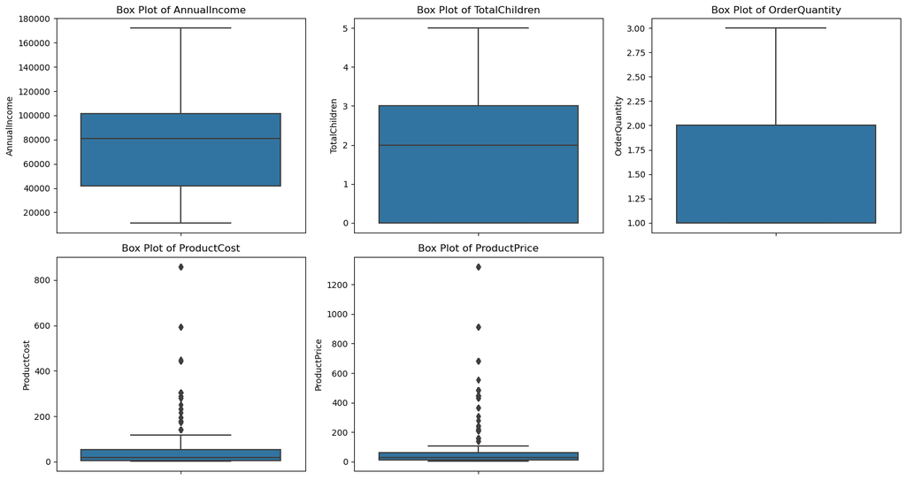

```python
import pandas as pd
import matplotlib.pyplot as plt
import seaborn as sns


# Columns of interest
columns_of_interest = ['AnnualIncome', 'TotalChildren', 'OrderQuantity', 'ProductCost', 'ProductPrice']

# Plotting box plots for each column
plt.figure(figsize=(15, 8))

for i, column in enumerate(columns_of_interest, 1):
    plt.subplot(2, 3, i)  # Adjust the layout as needed
    sns.boxplot(data=final_merged_with_products_df, y=column)
    plt.title(f'Box Plot of {column}')
    plt.ylabel(column)

plt.tight_layout()
plt.show()
```

```python
final_merged_with_products_df
```

|  | CustomerID | Prefix | FirstName | LastName | BirthDate | MaritalStatus | Gender | EmailAddress | AnnualIncome | TotalChildren | ... | SubCatergory_id | ProductSKU | ProductName | ModelName | ProductDescription | ProductColor | ProductSize | ProductStyle | ProductCost | ProductPrice |
| --- | --- | --- | --- | --- | --- | --- | --- | --- | --- | --- | --- | --- | --- | --- | --- | --- | --- | --- | --- | --- | --- |
| 0 | 121090 | MR. | Connor | Zimmerman | 7/26/1959 | S | M | Connor20@gmail.com | 91574 | 2 | ... | 19 | NRSEGS9HHFNXFJYR | Radhesh Creation Crystal Yellow Gold Plated Br... | Radhesh Creation | Key Features of Radhesh Creation Crystal Yello... | Orange | U | E | 4.842233 | 9.684466 |
| 1 | 121090 | MR. | Connor | Zimmerman | 7/26/1959 | S | M | Connor20@gmail.com | 91574 | 2 | ... | 19 | NRSEGS9HHFNXFJYR | Radhesh Creation Crystal Yellow Gold Plated Br... | Radhesh Creation | Key Features of Radhesh Creation Crystal Yello... | Orange | U | E | 4.842233 | 9.684466 |
| 2 | 121090 | MR. | Connor | Zimmerman | 7/26/1959 | S | M | Connor20@gmail.com | 91574 | 2 | ... | 19 | NRSEGS9HHFNXFJYR | Radhesh Creation Crystal Yellow Gold Plated Br... | Radhesh Creation | Key Features of Radhesh Creation Crystal Yello... | Orange | U | E | 4.842233 | 9.684466 |
| 3 | 121191 | MRS. | Genesis | Rodriguez | 7/19/1947 | S | F | Genesis751@hotmail.com | 71864 | 5 | ... | 19 | NRSEGS9HHFNXFJYR | Radhesh Creation Crystal Yellow Gold Plated Br... | Radhesh Creation | Key Features of Radhesh Creation Crystal Yello... | Orange | U | E | 4.842233 | 9.684466 |
| 4 | 121191 | MRS. | Genesis | Rodriguez | 7/19/1947 | S | F | Genesis751@hotmail.com | 71864 | 5 | ... | 19 | NRSEGS9HHFNXFJYR | Radhesh Creation Crystal Yellow Gold Plated Br... | Radhesh Creation | Key Features of Radhesh Creation Crystal Yello... | Orange | U | E | 4.842233 | 9.684466 |
| ... | ... | ... | ... | ... | ... | ... | ... | ... | ... | ... | ... | ... | ... | ... | ... | ... | ... | ... | ... | ... | ... |
| 2519 | 125652 | MRS. | Emma | Reed | 12/2/1962 | M | F | Emma363@yahoo.com | 31382 | 4 | ... | 3 | CWDEGKMAD2BWGAWR | Anmol Cotton Collapsible Wardrobe | Anmol | Specifications of Anmol Cotton Collapsible War... | Blue | U | E | 8.483010 | 15.764563 |
| 2520 | 125661 | MR. | Benjamin | Wood | 3/2/1961 | M | M | Benjamin970@outlook.com | 31638 | 3 | ... | 3 | CWDEGKMAD2BWGAWR | Anmol Cotton Collapsible Wardrobe | Anmol | Specifications of Anmol Cotton Collapsible War... | Blue | U | E | 8.483010 | 15.764563 |
| 2521 | 125661 | MR. | Benjamin | Wood | 3/2/1961 | M | M | Benjamin970@outlook.com | 31638 | 3 | ... | 3 | CWDEGKMAD2BWGAWR | Anmol Cotton Collapsible Wardrobe | Anmol | Specifications of Anmol Cotton Collapsible War... | Blue | U | E | 8.483010 | 15.764563 |
| 2522 | 125661 | MR. | Benjamin | Wood | 3/2/1961 | M | M | Benjamin970@outlook.com | 31638 | 3 | ... | 3 | CWDEGKMAD2BWGAWR | Anmol Cotton Collapsible Wardrobe | Anmol | Specifications of Anmol Cotton Collapsible War... | Blue | U | E | 8.483010 | 15.764563 |
| 2523 | 125661 | MR. | Benjamin | Wood | 3/2/1961 | M | M | Benjamin970@outlook.com | 31638 | 3 | ... | 3 | CWDEGKMAD2BWGAWR | Anmol Cotton Collapsible Wardrobe | Anmol | Specifications of Anmol Cotton Collapsible War... | Blue | U | E | 8.483010 | 15.764563 |

2524 rows × 47 columns

```python
import pandas as pd
import matplotlib.pyplot as plt
import seaborn as sns
from matplotlib.backends.backend_pdf import PdfPages
import os


# Define the directory and file path
new_directory = "D:\\Magnus"
pdf_file_path = os.path.join(new_directory, 'column_distributions.pdf')

# Set up the PDF document
with PdfPages(pdf_file_path) as pdf:

    # Distribution of numerical columns
    numerical_columns = final_merged_with_products_df.select_dtypes(include=['int64', 'float64']).columns
    for column in numerical_columns:
        plt.figure(figsize=(8, 4))
        sns.histplot(final_merged_with_products_df[column], kde=True, bins=30)
        plt.title(f'Distribution of {column}')
        plt.xlabel(column)
        plt.ylabel('Frequency')
        pdf.savefig()  # Save the current figure into the PDF
        plt.close()    # Close the figure to free memory

    # Distribution of categorical columns
    categorical_columns = final_merged_with_products_df.select_dtypes(include=['object']).columns
    for column in categorical_columns:
        plt.figure(figsize=(10, 4))
        sns.countplot(data=final_merged_with_products_df, x=column, order=final_merged_with_products_df[column].value_counts().index)
        plt.xticks(rotation=90)
        plt.title(f'Distribution of {column}')
        plt.xlabel(column)
        plt.ylabel('Count')
        pdf.savefig()  # Save the current figure into the PDF
        plt.close()    # Close the figure to free memory

print(f"PDF file saved at: {pdf_file_path}")
```

```
PDF file saved at: D:\Magnus\column_distributions.pdf
```

```python
#To get the first one to 5 coulmn across first two rows:
final_merged_with_products_df.iloc[1:3,1:6]
```

|  | Prefix | FirstName | LastName | BirthDate | MaritalStatus |
| --- | --- | --- | --- | --- | --- |
| 1 | MR. | Connor | Zimmerman | 7/26/1959 | S |
| 2 | MR. | Connor | Zimmerman | 7/26/1959 | S |

```python
#Last five column of the datasets
final_merged_with_products_df.iloc[-5:]
```

|  | CustomerID | Prefix | FirstName | LastName | BirthDate | MaritalStatus | Gender | EmailAddress | AnnualIncome | TotalChildren | ... | SubCatergory_id | ProductSKU | ProductName | ModelName | ProductDescription | ProductColor | ProductSize | ProductStyle | ProductCost | ProductPrice |
| --- | --- | --- | --- | --- | --- | --- | --- | --- | --- | --- | --- | --- | --- | --- | --- | --- | --- | --- | --- | --- | --- |
| 2519 | 125652 | MRS. | Emma | Reed | 12/2/1962 | M | F | Emma363@yahoo.com | 31382 | 4 | ... | 3 | CWDEGKMAD2BWGAWR | Anmol Cotton Collapsible Wardrobe | Anmol | Specifications of Anmol Cotton Collapsible War... | Blue | U | E | 8.48301 | 15.764563 |
| 2520 | 125661 | MR. | Benjamin | Wood | 3/2/1961 | M | M | Benjamin970@outlook.com | 31638 | 3 | ... | 3 | CWDEGKMAD2BWGAWR | Anmol Cotton Collapsible Wardrobe | Anmol | Specifications of Anmol Cotton Collapsible War... | Blue | U | E | 8.48301 | 15.764563 |
| 2521 | 125661 | MR. | Benjamin | Wood | 3/2/1961 | M | M | Benjamin970@outlook.com | 31638 | 3 | ... | 3 | CWDEGKMAD2BWGAWR | Anmol Cotton Collapsible Wardrobe | Anmol | Specifications of Anmol Cotton Collapsible War... | Blue | U | E | 8.48301 | 15.764563 |
| 2522 | 125661 | MR. | Benjamin | Wood | 3/2/1961 | M | M | Benjamin970@outlook.com | 31638 | 3 | ... | 3 | CWDEGKMAD2BWGAWR | Anmol Cotton Collapsible Wardrobe | Anmol | Specifications of Anmol Cotton Collapsible War... | Blue | U | E | 8.48301 | 15.764563 |
| 2523 | 125661 | MR. | Benjamin | Wood | 3/2/1961 | M | M | Benjamin970@outlook.com | 31638 | 3 | ... | 3 | CWDEGKMAD2BWGAWR | Anmol Cotton Collapsible Wardrobe | Anmol | Specifications of Anmol Cotton Collapsible War... | Blue | U | E | 8.48301 | 15.764563 |

5 rows × 47 columns

```python
#To retrieve the first row of the datasets
final_merged_with_products_df.iloc[0]
```

```
CustomerID                                                       121090
Prefix                                                              MR.
FirstName                                                        Connor
LastName                                                      Zimmerman
BirthDate                                                     7/26/1959
MaritalStatus                                                         S
Gender                                                                M
EmailAddress                                         Connor20@gmail.com
AnnualIncome                                                      91574
TotalChildren                                                         2
EducationLevel                                          Partial College
Occupation                                                 Professional
HomeOwner                                                             Y
OrderDate_x                                                    2/7/2015
StockDate_x                                                    1/8/2002
OrderNumber_x                                                   SO45389
Product_ID_x                                                        310
Customer_ID_x                                                    121090
Territory_ID_x                                                        4
OrderLineItem_x                                                       1
OrderQuantity_x                                                       1
OrderDate_y                                                   7/31/2016
StockDate_y                                                    6/3/2003
OrderNumber_y                                                   SO51679
Product_ID_y                                                        462
Customer_ID_y                                                    121090
Territory_ID_y                                                        4
OrderLineItem_y                                                       3
OrderQuantity_y                                                       2
OrderDate                                                     5/24/2017
StockDate                                                     1/28/2004
OrderNumber                                                     SO71269
Product_ID                                                          223
Customer_ID                                                      121090
Territory_ID                                                          4
OrderLineItem                                                         2
OrderQuantity                                                         3
SubCatergory_id                                                      19
ProductSKU                                             NRSEGS9HHFNXFJYR
ProductName           Radhesh Creation Crystal Yellow Gold Plated Br...
ModelName                                              Radhesh Creation
ProductDescription    Key Features of Radhesh Creation Crystal Yello...
ProductColor                                                     Orange
ProductSize                                                           U
ProductStyle                                                          E
ProductCost                                                    4.842233
ProductPrice                                                   9.684466
Name: 0, dtype: object
```

```python
#To retrieve the first 7 rows and first 5 column of the datasets
final_merged_with_products_df.iloc[1:8,1:6]
```

|  | Prefix | FirstName | LastName | BirthDate | MaritalStatus |
| --- | --- | --- | --- | --- | --- |
| 1 | MR. | Connor | Zimmerman | 7/26/1959 | S |
| 2 | MR. | Connor | Zimmerman | 7/26/1959 | S |
| 3 | MRS. | Genesis | Rodriguez | 7/19/1947 | S |
| 4 | MRS. | Genesis | Rodriguez | 7/19/1947 | S |
| 5 | MRS. | Genesis | Rodriguez | 7/19/1947 | S |
| 6 | MR. | Lucas | Gray | 10/20/1933 | S |
| 7 | MR. | Lucas | Gray | 10/20/1933 | S |

```python
#Or
final_merged_with_products_df.iloc[[1,2,3,4,5,6,7],1:6]
```

|  | Prefix | FirstName | LastName | BirthDate | MaritalStatus |
| --- | --- | --- | --- | --- | --- |
| 1 | MR. | Connor | Zimmerman | 7/26/1959 | S |
| 2 | MR. | Connor | Zimmerman | 7/26/1959 | S |
| 3 | MRS. | Genesis | Rodriguez | 7/19/1947 | S |
| 4 | MRS. | Genesis | Rodriguez | 7/19/1947 | S |
| 5 | MRS. | Genesis | Rodriguez | 7/19/1947 | S |
| 6 | MR. | Lucas | Gray | 10/20/1933 | S |
| 7 | MR. | Lucas | Gray | 10/20/1933 | S |

```python
#Retrieve the value for the 2 second row for column Birthdate
final_merged_with_products_df.loc[0,'BirthDate']
```

```
'7/26/1959'
```

```python
#Retrieve all the row where the first name is Connor
final_merged_with_products_df.loc[final_merged_with_products_df.FirstName=="Connor"]
```

|  | CustomerID | Prefix | FirstName | LastName | BirthDate | MaritalStatus | Gender | EmailAddress | AnnualIncome | TotalChildren | ... | SubCatergory_id | ProductSKU | ProductName | ModelName | ProductDescription | ProductColor | ProductSize | ProductStyle | ProductCost | ProductPrice |
| --- | --- | --- | --- | --- | --- | --- | --- | --- | --- | --- | --- | --- | --- | --- | --- | --- | --- | --- | --- | --- | --- |
| 0 | 121090 | MR. | Connor | Zimmerman | 7/26/1959 | S | M | Connor20@gmail.com | 91574 | 2 | ... | 19 | NRSEGS9HHFNXFJYR | Radhesh Creation Crystal Yellow Gold Plated Br... | Radhesh Creation | Key Features of Radhesh Creation Crystal Yello... | Orange | U | E | 4.842233 | 9.684466 |
| 1 | 121090 | MR. | Connor | Zimmerman | 7/26/1959 | S | M | Connor20@gmail.com | 91574 | 2 | ... | 19 | NRSEGS9HHFNXFJYR | Radhesh Creation Crystal Yellow Gold Plated Br... | Radhesh Creation | Key Features of Radhesh Creation Crystal Yello... | Orange | U | E | 4.842233 | 9.684466 |
| 2 | 121090 | MR. | Connor | Zimmerman | 7/26/1959 | S | M | Connor20@gmail.com | 91574 | 2 | ... | 19 | NRSEGS9HHFNXFJYR | Radhesh Creation Crystal Yellow Gold Plated Br... | Radhesh Creation | Key Features of Radhesh Creation Crystal Yello... | Orange | U | E | 4.842233 | 9.684466 |
| 147 | 121090 | MR. | Connor | Zimmerman | 7/26/1959 | S | M | Connor20@gmail.com | 91574 | 2 | ... | 3 | BEMEEZ6HPTQAAG3S | Springwel Single Spring Mattress | Springwel | Key Features of Springwel Single Spring Mattre... | Blue | 84x42 | 0 | 249.696602 | 309.223301 |
| 148 | 121090 | MR. | Connor | Zimmerman | 7/26/1959 | S | M | Connor20@gmail.com | 91574 | 2 | ... | 3 | BEMEEZ6HPTQAAG3S | Springwel Single Spring Mattress | Springwel | Key Features of Springwel Single Spring Mattre... | Blue | 84x42 | 0 | 249.696602 | 309.223301 |
| 149 | 121090 | MR. | Connor | Zimmerman | 7/26/1959 | S | M | Connor20@gmail.com | 91574 | 2 | ... | 3 | BEMEEZ6HPTQAAG3S | Springwel Single Spring Mattress | Springwel | Key Features of Springwel Single Spring Mattre... | Blue | 84x42 | 0 | 249.696602 | 309.223301 |
| 816 | 125653 | MR. | Connor | Hall | 12/4/1962 | S | M | Connor363@gmail.com | 31639 | 3 | ... | 3 | BEMEEZ6DCHGKSYHU | Springwel Single Spring Mattress | Springwel | Key Features of Springwel Single Spring Mattre... | Blue | 78x36 | 0 | 194.502427 | 240.873786 |
| 817 | 125653 | MR. | Connor | Hall | 12/4/1962 | S | M | Connor363@gmail.com | 31639 | 3 | ... | 3 | BEMEEZ6DCHGKSYHU | Springwel Single Spring Mattress | Springwel | Key Features of Springwel Single Spring Mattre... | Blue | 78x36 | 0 | 194.502427 | 240.873786 |
| 818 | 125653 | MR. | Connor | Hall | 12/4/1962 | S | M | Connor363@gmail.com | 31639 | 3 | ... | 3 | BEMEEZ6DCHGKSYHU | Springwel Single Spring Mattress | Springwel | Key Features of Springwel Single Spring Mattre... | Blue | 78x36 | 0 | 194.502427 | 240.873786 |
| 819 | 125653 | MR. | Connor | Hall | 12/4/1962 | S | M | Connor363@gmail.com | 31639 | 3 | ... | 3 | BEMEEZ6DCHGKSYHU | Springwel Single Spring Mattress | Springwel | Key Features of Springwel Single Spring Mattre... | Blue | 78x36 | 0 | 194.502427 | 240.873786 |
| 820 | 125653 | MR. | Connor | Hall | 12/4/1962 | S | M | Connor363@gmail.com | 31639 | 3 | ... | 3 | BEMEEZ6DCHGKSYHU | Springwel Single Spring Mattress | Springwel | Key Features of Springwel Single Spring Mattre... | Blue | 78x36 | 0 | 194.502427 | 240.873786 |
| 859 | 121942 | MR. | Connor | Baker | 10/30/1950 | M | M | Connor39@gmail.com | 21368 | 2 | ... | 31 | MTYEGYZZDG269NCS | Fun Box Dancing Duck | Fun Box | Key Features of Fun Box Dancing Duck Min Age: ... | Blue | U | 0 | 4.356796 | 6.055825 |
| 860 | 121942 | MR. | Connor | Baker | 10/30/1950 | M | M | Connor39@gmail.com | 21368 | 2 | ... | 31 | MTYEGYZZDG269NCS | Fun Box Dancing Duck | Fun Box | Key Features of Fun Box Dancing Duck Min Age: ... | Blue | U | 0 | 4.356796 | 6.055825 |
| 861 | 121942 | MR. | Connor | Baker | 10/30/1950 | M | M | Connor39@gmail.com | 21368 | 2 | ... | 31 | MTYEGYZZDG269NCS | Fun Box Dancing Duck | Fun Box | Key Features of Fun Box Dancing Duck Min Age: ... | Blue | U | 0 | 4.356796 | 6.055825 |
| 862 | 121942 | MR. | Connor | Baker | 10/30/1950 | M | M | Connor39@gmail.com | 21368 | 2 | ... | 31 | MTYEGYZZDG269NCS | Fun Box Dancing Duck | Fun Box | Key Features of Fun Box Dancing Duck Min Age: ... | Blue | U | 0 | 4.356796 | 6.055825 |
| 944 | 125653 | MR. | Connor | Hall | 12/4/1962 | S | M | Connor363@gmail.com | 31639 | 3 | ... | 31 | MTYEGYZZDG269NCS | Fun Box Dancing Duck | Fun Box | Key Features of Fun Box Dancing Duck Min Age: ... | Blue | U | 0 | 4.356796 | 6.055825 |
| 945 | 125653 | MR. | Connor | Hall | 12/4/1962 | S | M | Connor363@gmail.com | 31639 | 3 | ... | 31 | MTYEGYZZDG269NCS | Fun Box Dancing Duck | Fun Box | Key Features of Fun Box Dancing Duck Min Age: ... | Blue | U | 0 | 4.356796 | 6.055825 |
| 946 | 125653 | MR. | Connor | Hall | 12/4/1962 | S | M | Connor363@gmail.com | 31639 | 3 | ... | 31 | MTYEGYZZDG269NCS | Fun Box Dancing Duck | Fun Box | Key Features of Fun Box Dancing Duck Min Age: ... | Blue | U | 0 | 4.356796 | 6.055825 |
| 947 | 125653 | MR. | Connor | Hall | 12/4/1962 | S | M | Connor363@gmail.com | 31639 | 3 | ... | 31 | MTYEGYZZDG269NCS | Fun Box Dancing Duck | Fun Box | Key Features of Fun Box Dancing Duck Min Age: ... | Blue | U | 0 | 4.356796 | 6.055825 |
| 948 | 125653 | MR. | Connor | Hall | 12/4/1962 | S | M | Connor363@gmail.com | 31639 | 3 | ... | 31 | MTYEGYZZDG269NCS | Fun Box Dancing Duck | Fun Box | Key Features of Fun Box Dancing Duck Min Age: ... | Blue | U | 0 | 4.356796 | 6.055825 |
| 1053 | 122991 | MR. | Connor | Gray | 8/30/1969 | M | M | Connor677@yahoo.com | 61781 | 2 | ... | 31 | MTYEGGH4HHTY5FHN | Airwind Xylophone001 | Airwind | Key Features of Airwind Xylophone001 Min Age: ... | Other | U | 0 | 3.580097 | 6.189320 |
| 1054 | 122991 | MR. | Connor | Gray | 8/30/1969 | M | M | Connor677@yahoo.com | 61781 | 2 | ... | 31 | MTYEGGH4HHTY5FHN | Airwind Xylophone001 | Airwind | Key Features of Airwind Xylophone001 Min Age: ... | Other | U | 0 | 3.580097 | 6.189320 |
| 1055 | 122991 | MR. | Connor | Gray | 8/30/1969 | M | M | Connor677@yahoo.com | 61781 | 2 | ... | 31 | MTYEGGH4HHTY5FHN | Airwind Xylophone001 | Airwind | Key Features of Airwind Xylophone001 Min Age: ... | Other | U | 0 | 3.580097 | 6.189320 |
| 1056 | 122991 | MR. | Connor | Gray | 8/30/1969 | M | M | Connor677@yahoo.com | 61781 | 2 | ... | 31 | MTYEGGH4HHTY5FHN | Airwind Xylophone001 | Airwind | Key Features of Airwind Xylophone001 Min Age: ... | Other | U | 0 | 3.580097 | 6.189320 |
| 1151 | 122210 | MR. | Connor | Gonzalez | 3/31/1980 | M | M | Connor989@hotmail.com | 11527 | 0 | ... | 3 | KBBEFTKDHNZMCHSK | ORKA Leatherette XXXL Teardrop Kid Bean Bag | ORKA | ORKA Leatherette XXXL Teardrop Kid Bean Bag (B... | Blue | XXL | E | 24.259709 | 27.170874 |
| 1152 | 122210 | MR. | Connor | Gonzalez | 3/31/1980 | M | M | Connor989@hotmail.com | 11527 | 0 | ... | 3 | KBBEFTKDHNZMCHSK | ORKA Leatherette XXXL Teardrop Kid Bean Bag | ORKA | ORKA Leatherette XXXL Teardrop Kid Bean Bag (B... | Blue | XXL | E | 24.259709 | 27.170874 |
| 1153 | 122210 | MR. | Connor | Gonzalez | 3/31/1980 | M | M | Connor989@hotmail.com | 11527 | 0 | ... | 3 | KBBEFTKDHNZMCHSK | ORKA Leatherette XXXL Teardrop Kid Bean Bag | ORKA | ORKA Leatherette XXXL Teardrop Kid Bean Bag (B... | Blue | XXL | E | 24.259709 | 27.170874 |
| 1397 | 121942 | MR. | Connor | Baker | 10/30/1950 | M | M | Connor39@gmail.com | 21368 | 2 | ... | 3 | PLLEHQV78ZFHTE7X | IBS Plastic Portable Laptop Table | IBS | Key Features of IBS Plastic Portable Laptop Ta... | Beige | U | E | 16.978155 | 30.327670 |
| 1398 | 121942 | MR. | Connor | Baker | 10/30/1950 | M | M | Connor39@gmail.com | 21368 | 2 | ... | 3 | PLLEHQV78ZFHTE7X | IBS Plastic Portable Laptop Table | IBS | Key Features of IBS Plastic Portable Laptop Ta... | Beige | U | E | 16.978155 | 30.327670 |
| 1399 | 121942 | MR. | Connor | Baker | 10/30/1950 | M | M | Connor39@gmail.com | 21368 | 2 | ... | 3 | PLLEHQV78ZFHTE7X | IBS Plastic Portable Laptop Table | IBS | Key Features of IBS Plastic Portable Laptop Ta... | Beige | U | E | 16.978155 | 30.327670 |
| 1400 | 121942 | MR. | Connor | Baker | 10/30/1950 | M | M | Connor39@gmail.com | 21368 | 2 | ... | 3 | PLLEHQV78ZFHTE7X | IBS Plastic Portable Laptop Table | IBS | Key Features of IBS Plastic Portable Laptop Ta... | Beige | U | E | 16.978155 | 30.327670 |
| 1486 | 122210 | MR. | Connor | Gonzalez | 3/31/1980 | M | M | Connor989@hotmail.com | 11527 | 0 | ... | 31 | MTYEGUA2VUJ9UDGX | Dinoimpex Balloon and Beyblade Set Combo | Dinoimpex | Key Features of Dinoimpex Balloon and Beyblade... | Other | U | 0 | 5.084951 | 13.337379 |
| 1487 | 122210 | MR. | Connor | Gonzalez | 3/31/1980 | M | M | Connor989@hotmail.com | 11527 | 0 | ... | 31 | MTYEGUA2VUJ9UDGX | Dinoimpex Balloon and Beyblade Set Combo | Dinoimpex | Key Features of Dinoimpex Balloon and Beyblade... | Other | U | 0 | 5.084951 | 13.337379 |
| 1488 | 122210 | MR. | Connor | Gonzalez | 3/31/1980 | M | M | Connor989@hotmail.com | 11527 | 0 | ... | 31 | MTYEGUA2VUJ9UDGX | Dinoimpex Balloon and Beyblade Set Combo | Dinoimpex | Key Features of Dinoimpex Balloon and Beyblade... | Other | U | 0 | 5.084951 | 13.337379 |
| 2308 | 122991 | MR. | Connor | Gray | 8/30/1969 | M | M | Connor677@yahoo.com | 61781 | 2 | ... | 1 | SOFE8HPYHFDGPFHV | Durian Tulsa Leatherette 3 Seater Sofa | Durian | Durian Tulsa Leatherette 3 Seater Sofa (Finish... | Chocolate | U | 0 | 593.992718 | 913.834951 |
| 2309 | 122991 | MR. | Connor | Gray | 8/30/1969 | M | M | Connor677@yahoo.com | 61781 | 2 | ... | 1 | SOFE8HPYHFDGPFHV | Durian Tulsa Leatherette 3 Seater Sofa | Durian | Durian Tulsa Leatherette 3 Seater Sofa (Finish... | Chocolate | U | 0 | 593.992718 | 913.834951 |
| 2310 | 122991 | MR. | Connor | Gray | 8/30/1969 | M | M | Connor677@yahoo.com | 61781 | 2 | ... | 1 | SOFE8HPYHFDGPFHV | Durian Tulsa Leatherette 3 Seater Sofa | Durian | Durian Tulsa Leatherette 3 Seater Sofa (Finish... | Chocolate | U | 0 | 593.992718 | 913.834951 |
| 2311 | 122991 | MR. | Connor | Gray | 8/30/1969 | M | M | Connor677@yahoo.com | 61781 | 2 | ... | 1 | SOFE8HPYHFDGPFHV | Durian Tulsa Leatherette 3 Seater Sofa | Durian | Durian Tulsa Leatherette 3 Seater Sofa (Finish... | Chocolate | U | 0 | 593.992718 | 913.834951 |

38 rows × 47 columns

```python
final_merged_with_products_df.loc[(final_merged_with_products_df.Prefix=="MR." )&(final_merged_with_products_df.AnnualIncome>100000)]
```

|  | CustomerID | Prefix | FirstName | LastName | BirthDate | MaritalStatus | Gender | EmailAddress | AnnualIncome | TotalChildren | ... | SubCatergory_id | ProductSKU | ProductName | ModelName | ProductDescription | ProductColor | ProductSize | ProductStyle | ProductCost | ProductPrice |
| --- | --- | --- | --- | --- | --- | --- | --- | --- | --- | --- | --- | --- | --- | --- | --- | --- | --- | --- | --- | --- | --- |
| 23 | 121422 | MR. | Parker | Rogers | 1/31/1948 | M | M | Parker350@gmail.com | 171838 | 4 | ... | 19 | NRSEGS9HHFNXFJYR | Radhesh Creation Crystal Yellow Gold Plated Br... | Radhesh Creation | Key Features of Radhesh Creation Crystal Yello... | Orange | U | E | 4.842233 | 9.684466 |
| 24 | 121422 | MR. | Parker | Rogers | 1/31/1948 | M | M | Parker350@gmail.com | 171838 | 4 | ... | 19 | NRSEGS9HHFNXFJYR | Radhesh Creation Crystal Yellow Gold Plated Br... | Radhesh Creation | Key Features of Radhesh Creation Crystal Yello... | Orange | U | E | 4.842233 | 9.684466 |
| 25 | 121422 | MR. | Parker | Rogers | 1/31/1948 | M | M | Parker350@gmail.com | 171838 | 4 | ... | 19 | NRSEGS9HHFNXFJYR | Radhesh Creation Crystal Yellow Gold Plated Br... | Radhesh Creation | Key Features of Radhesh Creation Crystal Yello... | Orange | U | E | 4.842233 | 9.684466 |
| 74 | 122123 | MR. | Logan | Sanchez | 12/29/1959 | M | M | Logan570@yahoo.com | 171978 | 2 | ... | 19 | NRSEGS9HHFNXFJYR | Radhesh Creation Crystal Yellow Gold Plated Br... | Radhesh Creation | Key Features of Radhesh Creation Crystal Yello... | Orange | U | E | 4.842233 | 9.684466 |
| 75 | 122123 | MR. | Logan | Sanchez | 12/29/1959 | M | M | Logan570@yahoo.com | 171978 | 2 | ... | 19 | NRSEGS9HHFNXFJYR | Radhesh Creation Crystal Yellow Gold Plated Br... | Radhesh Creation | Key Features of Radhesh Creation Crystal Yello... | Orange | U | E | 4.842233 | 9.684466 |
| ... | ... | ... | ... | ... | ... | ... | ... | ... | ... | ... | ... | ... | ... | ... | ... | ... | ... | ... | ... | ... | ... |
| 2423 | 122701 | MR. | Gabriel | Williams | 6/6/1973 | M | M | Gabriel550@gmail.com | 111468 | 0 | ... | 23 | JWSEJS7QG6UCWAAZ | KALYANI COVERING Brass, Copper, Crystal Jewel Set | KALYANI COVERING | Key Features of KALYANI COVERING Brass, Copper... | Multicolor | U | 0 | 4.854369 | 6.917476 |
| 2424 | 122701 | MR. | Gabriel | Williams | 6/6/1973 | M | M | Gabriel550@gmail.com | 111468 | 0 | ... | 23 | JWSEJS7QG6UCWAAZ | KALYANI COVERING Brass, Copper, Crystal Jewel Set | KALYANI COVERING | Key Features of KALYANI COVERING Brass, Copper... | Multicolor | U | 0 | 4.854369 | 6.917476 |
| 2425 | 122705 | MR. | Evan | Cooper | 1/30/1971 | M | M | Evan961@outlook.com | 151319 | 0 | ... | 23 | JWSEJS7QG6UCWAAZ | KALYANI COVERING Brass, Copper, Crystal Jewel Set | KALYANI COVERING | Key Features of KALYANI COVERING Brass, Copper... | Multicolor | U | 0 | 4.854369 | 6.917476 |
| 2426 | 122705 | MR. | Evan | Cooper | 1/30/1971 | M | M | Evan961@outlook.com | 151319 | 0 | ... | 23 | JWSEJS7QG6UCWAAZ | KALYANI COVERING Brass, Copper, Crystal Jewel Set | KALYANI COVERING | Key Features of KALYANI COVERING Brass, Copper... | Multicolor | U | 0 | 4.854369 | 6.917476 |
| 2427 | 122705 | MR. | Evan | Cooper | 1/30/1971 | M | M | Evan961@outlook.com | 151319 | 0 | ... | 23 | JWSEJS7QG6UCWAAZ | KALYANI COVERING Brass, Copper, Crystal Jewel Set | KALYANI COVERING | Key Features of KALYANI COVERING Brass, Copper... | Multicolor | U | 0 | 4.854369 | 6.917476 |

277 rows × 47 columns

```python
#Use of isin function
final_merged_with_products_df.FirstName.isin(['Parker','Logan'])
```

```
0       False
1       False
2       False
3       False
4       False
        ...
2519    False
2520    False
2521    False
2522    False
2523    False
Name: FirstName, Length: 2524, dtype: bool
```

```python
#Checking whether the FirstName function have the Null value or not
final_merged_with_products_df.FirstName.isnull()
```

```
0       False
1       False
2       False
3       False
4       False
        ...
2519    False
2520    False
2521    False
2522    False
2523    False
Name: FirstName, Length: 2524, dtype: bool
```

```python
import pandas as pd

# Assuming final_merged_with_products_df is your final merged DataFrame
# Handle NaN values by dropping them (or you can fill them with a value if preferred)
cleaned_df = final_merged_with_products_df.dropna()

# Calculate the correlation matrix
correlation_matrix = cleaned_df.corr()

# Print the correlation matrix
print(correlation_matrix)
```

```
                 CustomerID  AnnualIncome  TotalChildren  Product_ID_x  \
CustomerID         1.000000     -0.239704       0.106777      0.134223
AnnualIncome      -0.239704      1.000000       0.134308      0.224874
TotalChildren      0.106777      0.134308       1.000000      0.125577
Product_ID_x       0.134223      0.224874       0.125577      1.000000
Customer_ID_x      1.000000     -0.239704       0.106777      0.134223
Territory_ID_x    -0.073089     -0.161922      -0.291854      0.101402
OrderLineItem_x         NaN           NaN            NaN           NaN
OrderQuantity_x         NaN           NaN            NaN           NaN
Product_ID_y       0.085612     -0.035250       0.038042     -0.006562
Customer_ID_y      1.000000     -0.239704       0.106777      0.134223
Territory_ID_y    -0.073089     -0.161922      -0.291854      0.101402
OrderLineItem_y   -0.019182      0.037022       0.024375      0.024954
OrderQuantity_y   -0.050271      0.060179       0.020469      0.020261
Product_ID        -0.097339      0.023772      -0.050847     -0.092326
Customer_ID        1.000000     -0.239704       0.106777      0.134223
Territory_ID      -0.073089     -0.161922      -0.291854      0.101402
OrderLineItem      0.043079     -0.018541      -0.022007     -0.005623
OrderQuantity     -0.010539      0.053460      -0.021996     -0.044823
SubCatergory_id    0.029915      0.006029       0.011157      0.008848
ProductCost        0.189101     -0.033171       0.037225      0.077154
ProductPrice       0.193177     -0.034826       0.031426      0.080679

                 Customer_ID_x  Territory_ID_x  OrderLineItem_x  \
CustomerID            1.000000       -0.073089              NaN
AnnualIncome         -0.239704       -0.161922              NaN
TotalChildren         0.106777       -0.291854              NaN
Product_ID_x          0.134223        0.101402              NaN
Customer_ID_x         1.000000       -0.073089              NaN
Territory_ID_x       -0.073089        1.000000              NaN
OrderLineItem_x            NaN             NaN              NaN
OrderQuantity_x            NaN             NaN              NaN
Product_ID_y          0.085612        0.024186              NaN
Customer_ID_y         1.000000       -0.073089              NaN
Territory_ID_y       -0.073089        1.000000              NaN
OrderLineItem_y      -0.019182        0.032722              NaN
OrderQuantity_y      -0.050271        0.016640              NaN
Product_ID           -0.097339       -0.010982              NaN
Customer_ID           1.000000       -0.073089              NaN
Territory_ID         -0.073089        1.000000              NaN
```

[output cut: 84 more lines]

```
Product_ID_y        0.015662      0.017624
Customer_ID_y       0.189101      0.193177
Territory_ID_y     -0.007261     -0.000228
OrderLineItem_y    -0.031474     -0.029762
OrderQuantity_y    -0.010158     -0.009523
Product_ID          0.076177      0.048708
Customer_ID         0.189101      0.193177
Territory_ID       -0.007261     -0.000228
OrderLineItem      -0.369482     -0.356583
OrderQuantity      -0.243073     -0.231878
SubCatergory_id    -0.427836     -0.424155
ProductCost         1.000000      0.996269
ProductPrice        0.996269      1.000000

[21 rows x 21 columns]
```

```python
final_merged_with_products_df.columns
```

```
Index(['CustomerID', 'Prefix', 'FirstName', 'LastName', 'BirthDate',
       'MaritalStatus', 'Gender', 'EmailAddress', 'AnnualIncome',
       'TotalChildren', 'EducationLevel', 'Occupation', 'HomeOwner',
       'OrderDate_x', 'StockDate_x', 'OrderNumber_x', 'Product_ID_x',
       'Customer_ID_x', 'Territory_ID_x', 'OrderLineItem_x', 'OrderQuantity_x',
       'OrderDate_y', 'StockDate_y', 'OrderNumber_y', 'Product_ID_y',
       'Customer_ID_y', 'Territory_ID_y', 'OrderLineItem_y', 'OrderQuantity_y',
       'OrderDate', 'StockDate', 'OrderNumber', 'Product_ID', 'Customer_ID',
       'Territory_ID', 'OrderLineItem', 'OrderQuantity', 'SubCatergory_id',
       'ProductSKU', 'ProductName', 'ModelName', 'ProductDescription',
       'ProductColor', 'ProductSize', 'ProductStyle', 'ProductCost',
       'ProductPrice'],
      dtype='object')
```

```python
pip install seaborn matplotlib
```

```python
import pandas as pd
import seaborn as sns
import matplotlib as plt
cleaned_df= final_merged_with_products_df.dropna()
correlation_matrix=cleaned_df
plt.figure(figsize=(10,0))
sns.heatmap(correlation_matrix, annot=True, cmpan='coolwarm', fmt='.2f', vmin=-1, vmax=1)
plt.show()
```

[output not shown]

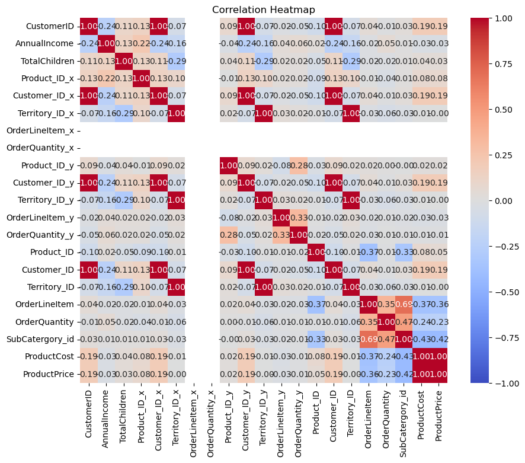

```python
import pandas as pd
import seaborn as sns
import matplotlib.pyplot as plt

# Assuming final_merged_with_products_df is your final merged DataFrame
# Handle NaN values by dropping them (or fill them if preferred)
cleaned_df = final_merged_with_products_df.dropna()

# Calculate the correlation matrix
correlation_matrix = cleaned_df.corr()

# Set up the matplotlib figure
plt.figure(figsize=(10, 8))

# Draw the heatmap
sns.heatmap(correlation_matrix, annot=True, cmap='coolwarm', fmt='.2f', vmin=-1, vmax=1)

# Set title
plt.title('Correlation Heatmap')

# Show the plot
plt.show()
```

```python
import pandas as pd

# Assuming final_merged_with_products_df is your final merged DataFrame
# Handle NaN values by dropping them (or fill them if preferred)
cleaned_df = final_merged_with_products_df.dropna()

# Calculate the correlation matrix
correlation_matrix = cleaned_df.corr()

# Get the list of variables included in the correlation matrix
variables = correlation_matrix.columns

# Print the list of variables
print("Variables included in the correlation matrix:")
print(variables)
```

```
Variables included in the correlation matrix:
Index(['CustomerID', 'AnnualIncome', 'TotalChildren', 'Product_ID_x',
       'Customer_ID_x', 'Territory_ID_x', 'OrderLineItem_x', 'OrderQuantity_x',
       'Product_ID_y', 'Customer_ID_y', 'Territory_ID_y', 'OrderLineItem_y',
       'OrderQuantity_y', 'Product_ID', 'Customer_ID', 'Territory_ID',
       'OrderLineItem', 'OrderQuantity', 'SubCatergory_id', 'ProductCost',
       'ProductPrice'],
      dtype='object')
```

```python
import pandas as pd

# Assuming final_merged_with_products_df is your final merged DataFrame
# Handle NaN values by dropping them (or fill them if preferred)
cleaned_df = final_merged_with_products_df.dropna()

# List of columns to exclude
columns_to_exclude = [
    'Product_ID_x', 'Customer_ID_x', 'Territory_ID_x', 'OrderLineItem_x', 'OrderQuantity_x',
    'Product_ID_y', 'Customer_ID_y', 'Territory_ID_y', 'OrderLineItem_y', 'OrderQuantity_y'
]

# Filter out columns to exclude
filtered_df = cleaned_df.drop(columns=[col for col in columns_to_exclude if col in cleaned_df.columns])

# Calculate the correlation matrix for the filtered DataFrame
correlation_matrix = filtered_df.corr()

# Print the correlation matrix
print(correlation_matrix)
```

```
                 CustomerID  AnnualIncome  TotalChildren  Product_ID  \
CustomerID         1.000000     -0.239704       0.106777   -0.097339
AnnualIncome      -0.239704      1.000000       0.134308    0.023772
TotalChildren      0.106777      0.134308       1.000000   -0.050847
Product_ID        -0.097339      0.023772      -0.050847    1.000000
Customer_ID        1.000000     -0.239704       0.106777   -0.097339
Territory_ID      -0.073089     -0.161922      -0.291854   -0.010982
OrderLineItem      0.043079     -0.018541      -0.022007   -0.368427
OrderQuantity     -0.010539      0.053460      -0.021996   -0.010025
SubCatergory_id    0.029915      0.006029       0.011157   -0.333011
ProductCost        0.189101     -0.033171       0.037225    0.076177
ProductPrice       0.193177     -0.034826       0.031426    0.048708

                 Customer_ID  Territory_ID  OrderLineItem  OrderQuantity  \
CustomerID          1.000000     -0.073089       0.043079      -0.010539
AnnualIncome       -0.239704     -0.161922      -0.018541       0.053460
TotalChildren       0.106777     -0.291854      -0.022007      -0.021996
Product_ID         -0.097339     -0.010982      -0.368427      -0.010025
Customer_ID         1.000000     -0.073089       0.043079      -0.010539
Territory_ID       -0.073089      1.000000      -0.029797      -0.061115
OrderLineItem       0.043079     -0.029797       1.000000       0.347553
OrderQuantity      -0.010539     -0.061115       0.347553       1.000000
SubCatergory_id     0.029915     -0.032772       0.687596       0.472087
ProductCost         0.189101     -0.007261      -0.369482      -0.243073
ProductPrice        0.193177     -0.000228      -0.356583      -0.231878

                 SubCatergory_id  ProductCost  ProductPrice
CustomerID              0.029915     0.189101      0.193177
AnnualIncome            0.006029    -0.033171     -0.034826
TotalChildren           0.011157     0.037225      0.031426
Product_ID             -0.333011     0.076177      0.048708
Customer_ID             0.029915     0.189101      0.193177
Territory_ID           -0.032772    -0.007261     -0.000228
OrderLineItem           0.687596    -0.369482     -0.356583
OrderQuantity           0.472087    -0.243073     -0.231878
SubCatergory_id         1.000000    -0.427836     -0.424155
ProductCost            -0.427836     1.000000      0.996269
ProductPrice           -0.424155     0.996269      1.000000
```

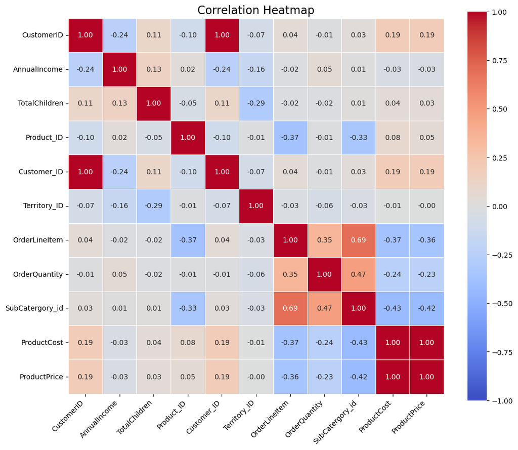

```python
import pandas as pd
import seaborn as sns
import matplotlib.pyplot as plt

# Assuming final_merged_with_products_df is your final merged DataFrame
# Handle NaN values by dropping them (or fill them if preferred)
cleaned_df = final_merged_with_products_df.dropna()

# List of columns to exclude
columns_to_exclude = [
    'Product_ID_x', 'Customer_ID_x', 'Territory_ID_x', 'OrderLineItem_x', 'OrderQuantity_x',
    'Product_ID_y', 'Customer_ID_y', 'Territory_ID_y', 'OrderLineItem_y', 'OrderQuantity_y'
]

# Filter out columns to exclude
filtered_df = cleaned_df.drop(columns=[col for col in columns_to_exclude if col in cleaned_df.columns])

# Calculate the correlation matrix for the filtered DataFrame
correlation_matrix = filtered_df.corr()

# Set up the matplotlib figure
plt.figure(figsize=(12, 10))

# Draw the heatmap
sns.heatmap(correlation_matrix, annot=True, cmap='coolwarm', fmt='.2f', vmin=-1, vmax=1, square=True, linewidths=0.5)

# Set the title and labels
plt.title('Correlation Heatmap', size=16)
plt.xticks(rotation=45, ha='right')
plt.yticks(rotation=0)

# Show the plot
plt.show()
```

```python
final_merged_with_products_df.columns
```

```
Index(['CustomerID', 'Prefix', 'FirstName', 'LastName', 'BirthDate',
       'MaritalStatus', 'Gender', 'EmailAddress', 'AnnualIncome',
       'TotalChildren', 'EducationLevel', 'Occupation', 'HomeOwner',
       'OrderDate_x', 'StockDate_x', 'OrderNumber_x', 'Product_ID_x',
       'Customer_ID_x', 'Territory_ID_x', 'OrderLineItem_x', 'OrderQuantity_x',
       'OrderDate_y', 'StockDate_y', 'OrderNumber_y', 'Product_ID_y',
       'Customer_ID_y', 'Territory_ID_y', 'OrderLineItem_y', 'OrderQuantity_y',
       'OrderDate', 'StockDate', 'OrderNumber', 'Product_ID', 'Customer_ID',
       'Territory_ID', 'OrderLineItem', 'OrderQuantity', 'SubCatergory_id',
       'ProductSKU', 'ProductName', 'ModelName', 'ProductDescription',
       'ProductColor', 'ProductSize', 'ProductStyle', 'ProductCost',
       'ProductPrice'],
      dtype='object')
```

```python
import pandas as pd
from sklearn.linear_model import LinearRegression
from sklearn.model_selection import train_test_split
from sklearn.metrics import mean_squared_error, r2_score

# Assuming final_merged_with_products_df is your DataFrame
# Select relevant columns
columns_of_interest = [
    'AnnualIncome', 'TotalChildren', 'OrderLineItem', 'OrderQuantity',
    'ProductSize', 'ProductCost', 'ProductPrice'
]

# Filter DataFrame to include only these columns
filtered_df = final_merged_with_products_df[columns_of_interest]

# Check for missing values
print(filtered_df.isnull().sum())  # Identify missing values

# Handle missing values (e.g., drop rows with missing values)
filtered_df = filtered_df.dropna()

# Define the dependent variable (target) and independent variables (predictors)
X = filtered_df.drop(columns='ProductPrice')
y = filtered_df['ProductPrice']

# Convert categorical variables to numeric using one-hot encoding if needed
# For instance, if 'OrderLineItem' or 'ProductSize' is categorical
X_encoded = pd.get_dummies(X, columns=['OrderLineItem', 'ProductSize'])

# Split the data into training and testing sets
X_train, X_test, y_train, y_test = train_test_split(X_encoded, y, test_size=0.2, random_state=42)

# Initialize and fit the regression model
model = LinearRegression()
model.fit(X_train, y_train)

# Make predictions
y_pred = model.predict(X_test)

# Print model coefficients
print("Intercept:", model.intercept_)
print("Coefficients:", model.coef_)

# Print evaluation metrics
print("Mean Squared Error:", mean_squared_error(y_test, y_pred))
print("R-squared:", r2_score(y_test, y_pred))
```

```
AnnualIncome     0
TotalChildren    0
OrderLineItem    0
OrderQuantity    0
ProductSize      0
ProductCost      0
ProductPrice     0
dtype: int64
Intercept: -24.293576798398917
Coefficients: [-1.25074725e-05 -3.66333129e-01 -2.16388939e+00  1.53696118e+00
 -4.66697324e+00 -2.22222082e+00 -5.40703223e+00  1.65568977e+00
  3.57582232e+00  7.06471420e+00  3.86616391e+01  4.21956978e+01
  3.55470887e+01 -1.78050753e+01 -2.55485870e+01 -1.01411822e+02
 -2.50277963e+01  2.36578872e+01  2.97309674e+01]
Mean Squared Error: 226.43871570908058
R-squared: 0.9949476401262763
```

```python
#Checking the behavious of model over training and testing datasets:
import pandas as pd
from sklearn.linear_model import LinearRegression
from sklearn.model_selection import train_test_split
from sklearn.metrics import mean_squared_error, r2_score

# Assuming final_merged_with_products_df is your DataFrame
# Select relevant columns
columns_of_interest = [
    'AnnualIncome', 'TotalChildren', 'OrderLineItem', 'OrderQuantity',
    'ProductSize', 'ProductCost', 'ProductPrice'
]

# Filter DataFrame to include only these columns
filtered_df = final_merged_with_products_df[columns_of_interest]

# Check for missing values and handle them
filtered_df = filtered_df.dropna()

# Define the dependent variable (target) and independent variables (predictors)
X = filtered_df.drop(columns='ProductPrice')
y = filtered_df['ProductPrice']

# Convert categorical variables to numeric using one-hot encoding if needed
X_encoded = pd.get_dummies(X, columns=['OrderLineItem', 'ProductSize'])

# Split the data into training and testing sets
X_train, X_test, y_train, y_test = train_test_split(X_encoded, y, test_size=0.2, random_state=42)

# Initialize and fit the regression model
model = LinearRegression()
model.fit(X_train, y_train)

# Make predictions on both training and testing sets
y_train_pred = model.predict(X_train)
y_test_pred = model.predict(X_test)

# Calculate metrics for training set
train_mse = mean_squared_error(y_train, y_train_pred)
train_r2 = r2_score(y_train, y_train_pred)

# Calculate metrics for testing set
test_mse = mean_squared_error(y_test, y_test_pred)
test_r2 = r2_score(y_test, y_test_pred)

# Print metrics
print("Training Mean Squared Error:", train_mse)
print("Training R-squared:", train_r2)
print("Testing Mean Squared Error:", test_mse)
print("Testing R-squared:", test_r2)
```

```
Training Mean Squared Error: 223.13096708149897
Training R-squared: 0.9951076779499679
Testing Mean Squared Error: 226.43871570908058
Testing R-squared: 0.9949476401262763
```

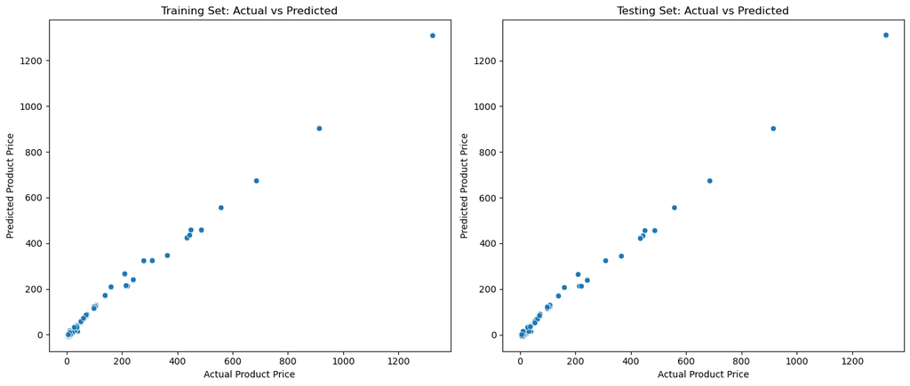

```python
import matplotlib.pyplot as plt
import seaborn as sns
import pandas as pd
from sklearn.linear_model import LinearRegression
from sklearn.model_selection import train_test_split
from sklearn.metrics import mean_squared_error, r2_score

# Assuming final_merged_with_products_df is your DataFrame
# Select relevant columns
columns_of_interest = [
    'AnnualIncome', 'TotalChildren', 'OrderLineItem', 'OrderQuantity',
    'ProductSize', 'ProductCost', 'ProductPrice'
]

# Filter DataFrame to include only these columns
filtered_df = final_merged_with_products_df[columns_of_interest]

# Check for missing values and handle them
filtered_df = filtered_df.dropna()

# Define the dependent variable (target) and independent variables (predictors)
X = filtered_df.drop(columns='ProductPrice')
y = filtered_df['ProductPrice']

# Convert categorical variables to numeric using one-hot encoding if needed
X_encoded = pd.get_dummies(X, columns=['OrderLineItem', 'ProductSize'])

# Split the data into training and testing sets
X_train, X_test, y_train, y_test = train_test_split(X_encoded, y, test_size=0.2, random_state=42)

# Initialize and fit the regression model
model = LinearRegression()
model.fit(X_train, y_train)

# Make predictions on both training and testing sets
y_train_pred = model.predict(X_train)
y_test_pred = model.predict(X_test)

# Plot predicted vs actual values for training set
plt.figure(figsize=(14, 6))

plt.subplot(1, 2, 1)
sns.scatterplot(x=y_train, y=y_train_pred)
plt.xlabel('Actual Product Price')
plt.ylabel('Predicted Product Price')
plt.title('Training Set: Actual vs Predicted')

# Plot predicted vs actual values for testing set
plt.subplot(1, 2, 2)
sns.scatterplot(x=y_test, y=y_test_pred)
plt.xlabel('Actual Product Price')
plt.ylabel('Predicted Product Price')
plt.title('Testing Set: Actual vs Predicted')

plt.tight_layout()
plt.show()
```

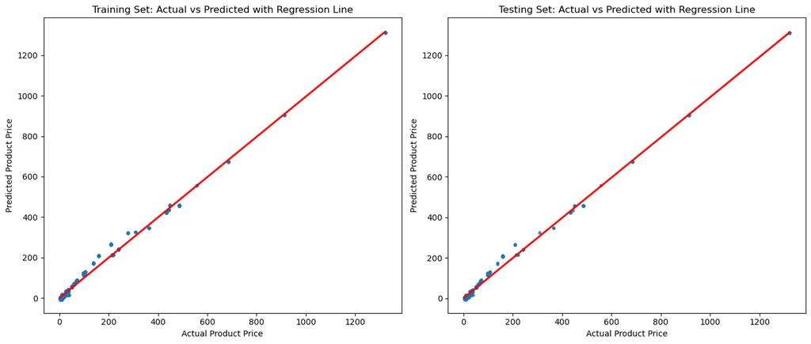

```python
import matplotlib.pyplot as plt
import seaborn as sns
import pandas as pd
from sklearn.linear_model import LinearRegression
from sklearn.model_selection import train_test_split
from sklearn.metrics import mean_squared_error, r2_score

# Assuming final_merged_with_products_df is your DataFrame
# Select relevant columns
columns_of_interest = [
    'AnnualIncome', 'TotalChildren', 'OrderLineItem', 'OrderQuantity',
    'ProductSize', 'ProductCost', 'ProductPrice'
]

# Filter DataFrame to include only these columns
filtered_df = final_merged_with_products_df[columns_of_interest]

# Check for missing values and handle them
filtered_df = filtered_df.dropna()

# Define the dependent variable (target) and independent variables (predictors)
X = filtered_df.drop(columns='ProductPrice')
y = filtered_df['ProductPrice']

# Convert categorical variables to numeric using one-hot encoding if needed
X_encoded = pd.get_dummies(X, columns=['OrderLineItem', 'ProductSize'])

# Split the data into training and testing sets
X_train, X_test, y_train, y_test = train_test_split(X_encoded, y, test_size=0.2, random_state=42)

# Initialize and fit the regression model
model = LinearRegression()
model.fit(X_train, y_train)

# Make predictions on both training and testing sets
y_train_pred = model.predict(X_train)
y_test_pred = model.predict(X_test)

# Plot predicted vs actual values for training set with regression line
plt.figure(figsize=(14, 6))

plt.subplot(1, 2, 1)
sns.regplot(x=y_train, y=y_train_pred, scatter_kws={'s':10}, line_kws={'color':'red'})
plt.xlabel('Actual Product Price')
plt.ylabel('Predicted Product Price')
plt.title('Training Set: Actual vs Predicted with Regression Line')

# Plot predicted vs actual values for testing set with regression line
plt.subplot(1, 2, 2)
sns.regplot(x=y_test, y=y_test_pred, scatter_kws={'s':10}, line_kws={'color':'red'})
plt.xlabel('Actual Product Price')
plt.ylabel('Predicted Product Price')
plt.title('Testing Set: Actual vs Predicted with Regression Line')

plt.tight_layout()
plt.show()
```

```python
#Now i want to know the estianmt, std error, p values and t value for each varaible
import pandas as pd
import statsmodels.api as sm
from sklearn.model_selection import train_test_split

# Assuming final_merged_with_products_df is your DataFrame
# Select relevant columns
columns_of_interest = [
    'AnnualIncome', 'TotalChildren', 'OrderLineItem', 'OrderQuantity',
    'ProductSize', 'ProductCost', 'ProductPrice'
]

# Filter DataFrame to include only these columns
filtered_df = final_merged_with_products_df[columns_of_interest]

# Check for missing values and handle them
filtered_df = filtered_df.dropna()

# Define the dependent variable (target) and independent variables (predictors)
X = filtered_df.drop(columns='ProductPrice')
y = filtered_df['ProductPrice']

# Convert categorical variables to numeric using one-hot encoding if needed
X_encoded = pd.get_dummies(X, columns=['OrderLineItem', 'ProductSize'])

# Add a constant to the model (intercept term)
X_encoded = sm.add_constant(X_encoded)

# Fit the model using statsmodels
model = sm.OLS(y, X_encoded).fit()

# Print the summary of the regression
print(model.summary())
```

```
                            OLS Regression Results
==============================================================================
Dep. Variable:           ProductPrice   R-squared:                       0.995
Model:                            OLS   Adj. R-squared:                  0.995
Method:                 Least Squares   F-statistic:                 2.981e+04
Date:                Thu, 05 Sep 2024   Prob (F-statistic):               0.00
Time:                        20:30:32   Log-Likelihood:                -10409.
No. Observations:                2524   AIC:                         2.085e+04
Df Residuals:                    2506   BIC:                         2.096e+04
Df Model:                          17
Covariance Type:            nonrobust
=====================================================================================
                        coef    std err          t      P>|t|      [0.025      0.975]
-------------------------------------------------------------------------------------
const               -19.1037      1.558    -12.261      0.000     -22.159     -16.048
AnnualIncome       -1.01e-05   8.56e-06     -1.180      0.238   -2.69e-05    6.69e-06
TotalChildren        -0.3126      0.182     -1.715      0.087      -0.670       0.045
OrderQuantity        -2.3815      0.662     -3.599      0.000      -3.679      -1.084
ProductCost           1.5390      0.003    609.808      0.000       1.534       1.544
OrderLineItem_1      -8.4461      1.126     -7.503      0.000     -10.653      -6.239
OrderLineItem_2      -5.0023      1.096     -4.566      0.000      -7.150      -2.854
OrderLineItem_3      -8.3418      1.187     -7.027      0.000     -10.670      -6.014
OrderLineItem_4      -1.1557      1.265     -0.913      0.361      -3.637       1.326
OrderLineItem_5       0.2397      1.958      0.122      0.903      -3.600       4.079
OrderLineItem_6       3.6024      5.267      0.684      0.494      -6.726      13.930
ProductSize_12       36.3279      1.468     24.745      0.000      33.449      39.207
ProductSize_15.6     39.9818      1.495     26.738      0.000      37.050      42.914
ProductSize_16       33.2225      2.427     13.687      0.000      28.463      37.982
ProductSize_72x30   -19.9698      3.884     -5.141      0.000     -27.586     -12.353
ProductSize_78x36   -27.3971      2.956     -9.268      0.000     -33.194     -21.600
ProductSize_78x48  -103.8286      6.829    -15.205      0.000    -117.219     -90.438
ProductSize_84x42   -27.2058      3.191     -8.525      0.000     -33.464     -20.948
ProductSize_U        21.5436      1.091     19.744      0.000      19.404      23.683
ProductSize_XXL      28.2217      1.636     17.251      0.000      25.014      31.430
==============================================================================
Omnibus:                      891.886   Durbin-Watson:                   0.070
Prob(Omnibus):                  0.000   Jarque-Bera (JB):             3145.286
Skew:                          -1.757   Prob(JB):                         0.00
Kurtosis:                       7.190   Cond. No.                     1.07e+21
==============================================================================

Notes:
[1] Standard Errors assume that the covariance matrix of the errors is correctly specified.
[2] The smallest eigenvalue is 1.6e-29. This might indicate that there are
strong multicollinearity problems or that the design matrix is singular.
```

# Summary of My OLS Regression Results:

R-squared and Adjusted R-squared:

R-squared: 0.995: This means that about 99.5% of the variance in ProductPrice is explained by the independent variables in my model. This high R-squared suggests that my model fits the data very well. Adjusted R-squared: 0.995: This value, which is close to the R-squared, adjusts for the number of predictors in my model. It indicates that the addition of predictors is justifiable and does not inflate the model's performance excessively. F-statistic and Prob (F-statistic):

F-statistic: 2.981e+04: This high value suggests that my model is a good fit for the data overall. Prob (F-statistic): 0.00: The low p-value indicates that my model's F-statistic is statistically significant, meaning the independent variables, as a group, are significantly related to ProductPrice. Coefficients (coef):

const (Intercept): -19.1037: This is the estimated ProductPrice when all predictors are zero. Although this value might not be meaningful if zero is not realistic for the predictors. AnnualIncome: -1.01e-05: This very small negative coefficient shows a minimal effect on ProductPrice. TotalChildren: -0.3126: This indicates a slight negative effect on ProductPrice. OrderQuantity: -2.3815: A negative coefficient means that as order quantity increases, the ProductPrice decreases. ProductCost: 1.5390: This positive coefficient suggests that higher product cost is associated with a higher ProductPrice. OrderLineItem and ProductSize: The coefficients for these categorical variables vary based on their levels, showing their effects on ProductPrice. Standard Error (std err):

These values give an estimate of the standard deviation of the coefficients. Smaller standard errors relative to the coefficients imply more precise estimates. t-value:

t-values are calculated by dividing the coefficient by its standard error. Higher absolute t-values indicate a stronger relationship between a predictor and the dependent variable. p-value (P>|t|):

The p-values indicate the probability of observing the t-value if the null hypothesis is true. Since most p-values are 0.000, it shows strong evidence against the null hypothesis (that the coefficient is zero). Confidence Intervals ([0.025, 0.975]):

These intervals provide a range where I can be 95% confident the true coefficient lies. For example, the coefficient for ProductCost is 1.5390 with a confidence interval of [1.534, 1.544], so I'm 95% confident the true coefficient is within this range. Additional Notes:

Omnibus: A high Omnibus value with a low p-value suggests that the residuals are not normally distributed. Durbin-Watson: 0.070: This value indicates strong positive autocorrelation in the residuals. Ideally, values close to 2 suggest no autocorrelation. Jarque-Bera (JB): The high value with a low p-value suggests that the residuals are not normally distributed. Cond. No. (Condition Number): A very high condition number (1.07e+21) suggests there may be multicollinearity issues or that the design matrix might be singular. Summary: My model has a very high R-squared value and significant p-values for most predictors, which means it fits the data well and the predictors are significant. However, I need to address the potential multicollinearity and autocorrelation issues to ensure the robustness of my model.

Key Results from the Regression Analysis: Intercept: -19.1037

This is the baseline value of ProductPrice when all independent variables are zero. However, it may not have a practical interpretation if zero values for all predictors are not realistic. AnnualIncome: -1.01e-05

p-value: 0.238 (Not statistically significant) Interpretation: The effect of AnnualIncome on ProductPrice is minimal and not statistically significant, indicating that changes in AnnualIncome do not meaningfully influence ProductPrice in this model. TotalChildren: -0.3126

p-value: 0.087 (Marginally significant, borderline) Interpretation: There is a negative relationship between TotalChildren and ProductPrice, but the effect is not strongly significant. This suggests that as the number of children increases, the ProductPrice might decrease slightly. OrderQuantity: -2.3815

p-value: 0.000 (Statistically significant) Interpretation: There is a significant negative relationship between OrderQuantity and ProductPrice. Higher order quantities are associated with a decrease in ProductPrice. ProductCost: 1.5390

p-value: 0.000 (Statistically significant) Interpretation: There is a strong positive relationship between ProductCost and ProductPrice. An increase in ProductCost is associated with a significant increase in ProductPrice. OrderLineItem (categorical variables):

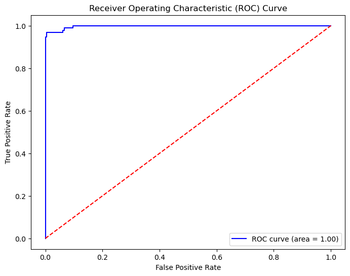

```
Confusion Matrix:
 [[409   2]
 [  3  91]]
Classification Report:
               precision    recall  f1-score   support

           0       0.99      1.00      0.99       411
           1       0.98      0.97      0.97        94

    accuracy                           0.99       505
   macro avg       0.99      0.98      0.98       505
weighted avg       0.99      0.99      0.99       505
```

```python
from sklearn.linear_model import LogisticRegression
from sklearn.metrics import roc_curve, auc, confusion_matrix, classification_report, roc_auc_score
import pandas as pd
from sklearn.model_selection import train_test_split

# Assuming final_merged_with_products_df is your DataFrame
# Select relevant columns
columns_of_interest = [
    'AnnualIncome', 'TotalChildren', 'OrderLineItem', 'OrderQuantity',
    'ProductSize', 'ProductCost', 'ProductPrice'
]

# Filter DataFrame to include only these columns
filtered_df = final_merged_with_products_df[columns_of_interest]

# Check for missing values and handle them
filtered_df = filtered_df.dropna()

# Define the dependent variable (target) and independent variables (predictors)
X = filtered_df.drop(columns='ProductPrice')
y = filtered_df['ProductPrice']

# Convert categorical variables to numeric using one-hot encoding if needed
X_encoded = pd.get_dummies(X, columns=['OrderLineItem', 'ProductSize'])

# Create a binary target based on a threshold for ProductPrice BEFORE splitting the data
threshold = 100  # Example threshold
y_binary = (y > threshold).astype(int)

# Split the data into training and testing sets
X_train, X_test, y_train_binary, y_test_binary = train_test_split(X_encoded, y_binary, test_size=0.2, random_state=42)

# Train a logistic regression model
logreg = LogisticRegression()
logreg.fit(X_train, y_train_binary)

# Predict probabilities
y_prob = logreg.predict_proba(X_test)[:, 1]

# Generate ROC curve
fpr, tpr, thresholds = roc_curve(y_test_binary, y_prob)
roc_auc = auc(fpr, tpr)

# Plot ROC curve
plt.figure(figsize=(8, 6))
plt.plot(fpr, tpr, color='blue', label=f'ROC curve (area = {roc_auc:.2f})')
plt.plot([0, 1], [0, 1], color='red', linestyle='--')
plt.xlabel('False Positive Rate')
plt.ylabel('True Positive Rate')
plt.title('Receiver Operating Characteristic (ROC) Curve')
plt.legend(loc='lower right')
plt.show()

# Confusion Matrix
y_pred = logreg.predict(X_test)
conf_matrix = confusion_matrix(y_test_binary, y_pred)
print('Confusion Matrix:\n', conf_matrix)

# Classification Report
print('Classification Report:\n', classification_report(y_test_binary, y_pred))
```

Let me break down what each of these terms means for me:

Confusion Matrix: True Positives (TP): These are the times I correctly predicted something as positive (like predicting someone has a disease when they actually do). In my confusion matrix, this is the 91 times I correctly predicted class 1. True Negatives (TN): These are the times I correctly predicted something as negative (like predicting someone doesn't have a disease when they really don’t). In my matrix, this is the 409 times I correctly predicted class 0. False Positives (FP): These are the times I incorrectly predicted something as positive when it was actually negative (like predicting someone has a disease when they don't). In my matrix, this is the 2 times I predicted class 1 when it was really class 0. False Negatives (FN): These are the times I incorrectly predicted something as negative when it was actually positive (like predicting someone doesn’t have a disease when they do). In my matrix, this is the 3 times I predicted class 0 when it was really class 1. Precision: Precision tells me how good I am at not labeling something positive when it’s actually negative. For example, if I predict that someone has a disease, precision tells me how often I’m right. Recall: Recall tells me how good I am at catching all the actual positives. For instance, if there are 100 people with a disease, recall tells me how many of those people I correctly identified. F1-Score: The F1-score is the balance between precision and recall. It gives me a single score that tells me how well I’m doing overall, considering both precision and recall. Support: Support is just the number of actual occurrences of each class in my dataset. It shows me how many times each class actually appeared in my data. Accuracy: Accuracy is how often I got things right overall. It’s the percentage of all my predictions that were correct. Macro Average: The macro average gives me the average of precision, recall, and F1-score across all classes, treating each class equally, regardless of how many times it appears in my data. Weighted Average: The weighted average is similar to the macro average, but it takes into account how many times each class appears. It’s like the macro average but gives more importance to the classes that appear more frequently. These metrics help me understand how well my model is performing, not just overall, but also for each class specifically.